# Exam 2 - Take Home

Jack Sarsen

2025-11-05

### Load Packages and Read Dataset

```r
pacman::p_load(tidyverse,readr,ggplot2,car,dplyr,knitr)

Cambridge <- read.csv("./data/Cambridge_USA.csv")
glimpse(Cambridge)
```

## 1. Explanatory Summary

The dataset Cambridge_USA.csv includes 21 variables and 1055 listings of Airbnb Properties in Cambridge, Massachusettes.

**Variables**

- id
- name (listing name)
- host id
- host name
- latitude
- longitude
- room type
- accommodates
- bathrooms
- bedrooms
- price
- minimum nights
- number of reviews
- neighborhood group (this column is mostly empty in the Cambridge dataset)
- neighborhood
- last review
- reviews per month
- calculated host listings count
- availability 365 (days per year)
- number of reviews ltm (in the past 12 months)
- license (license)

**Key Variables**

| Variable | Min | Max | Q1 | Q3 |
| --- | --- | --- | --- | --- |
| accommodates | 1.00 | 16.00 | 2.00 | 4.00 |
| bathrooms | 0.00 | 4.00 | 1.00 | 1.50 |
| bedrooms | 0.00 | 8.00 | 1.00 | 2.00 |
| price | 29.00 | 50031.00 | 105.00 | 322.00 |
| minimum_nights | 1.00 | 365.00 | 2.00 | 30.00 |
| number_of_reviews | 0.00 | 1038.00 | 1.00 | 64.50 |
| reviews_per_month | 0.01 | 24.22 | 0.2875 | 2.58 |
| calculated_host_listings_count | 1.00 | 169.00 | 2.00 | 33.00 |
| availability_365 | 0.00 | 365.00 | 131.00 | 304.00 |

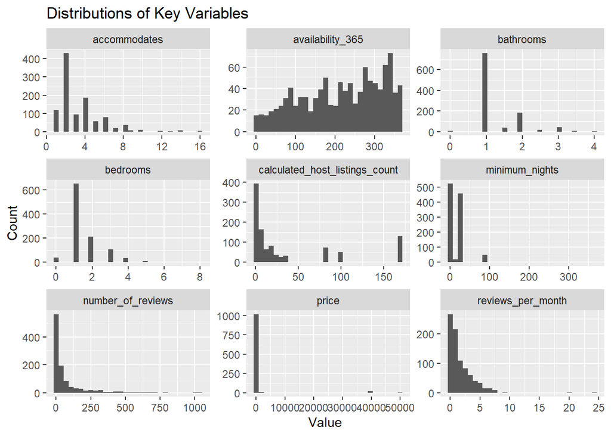

## 2. Initial Model

```r
model1 <- lm(price ~ room_type + accommodates + bathrooms + bedrooms , data = Cambridge)
summary(model1)
```

[output not shown]

**Estimate Regression Equations**

*Room_typePrivate room:-70.04*

Holding accommodates, bathrooms, and bedrooms constant, a private room is estimated to cost about $70.04 less per night than an entire home/atp.

*Accommodates:33.60* Holding room type, bathrooms, and number of bedrooms constant. The model estimates price per night increases by about $33.60 for each additional person the airbnb can accommodate for.

## 3. Model Refinement and Comparison

```r
model2 <- lm(price ~ room_type + accommodates + bathrooms + bedrooms + minimum_nights + availability_365 + calculated_host_listings_count, data = Cambridge)
```

Added three predictors: minimum_nights, avalability_365, and calculated_host_listings_count

```r
c(model1_adjR2 = summary(model1)$adj.r.squared,
  model2_adjR2 = summary(model2)$adj.r.squared
)
```

```
## model1_adjR2 model2_adjR2
##    0.9130819    0.9129179
```

Model 1 (R²=0.9131) and Model 2 (R² = 0.9129) produced essentially the same adjusted R² values indicating that both models explain the variation in price about the same. Because the additional predictors do not improve the fit. Model 1 is still preferable to model 2. It’s reduced complexity and easier ability to understand makes it the better choice

## 4. Diagnostic Analysis

**Before Cleaning**

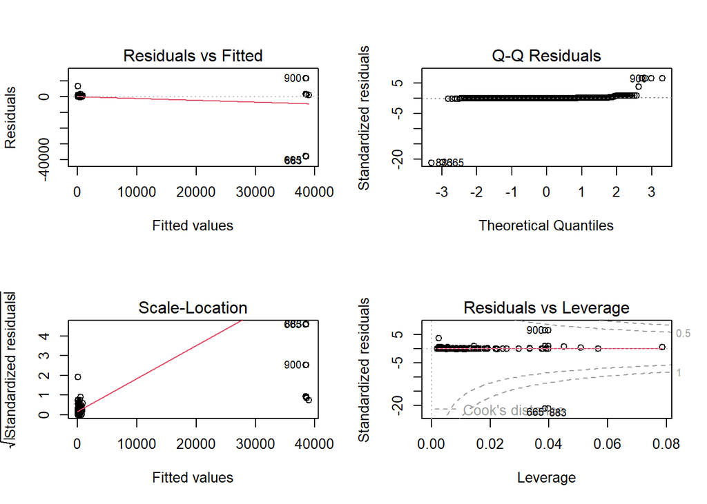

```r
par(mfrow = c(2,2))
plot(model1)
```

**After Cleaning**

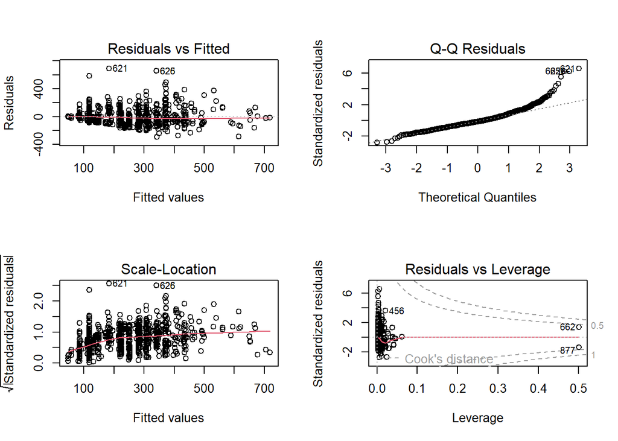

```r
Cleaned_Cambridge <- Cambridge %>%
  filter(price < 1000)
model_clean <- lm(price ~ room_type + accommodates + bathrooms + bedrooms, data = Cleaned_Cambridge)
par(mfrow = c(2,2))
plot(model_clean)
```

For this analysis I chose to trim the dataset by removing any extreme outliers with unusually high nightly prices. The initial diagnostic revealed a small number of listings with extremely large fitted values. These listings, which included prices exceeding 50,000 USD per night, were either of extreme luxury properties or more than likely just data entry errors. To ensure a more accurate representation of the data. I filtered the dataset to only include prices below 1,000 USD per night. This adjustment reduced the influcence of outliers and produced more evenly distributed residuals. Although some mild outliers still remain, the no longer have wild influence on the regression result.

## 5. Interpretation and Conclusions

**Summary of Findings**

Despite the efforts to trim the data by removing extreme outliers, the model still showed minor deviations from the normal, especially at higher prices. Future improvements could include additional predictors such as neighborhood, to help narrow down those “luxury” listings, and time of year. Overall, the model provided a reliable view of typical Airbnb pricing patterns while acknowledging the limitations.